# R Notebook

preview : *Ctrl+Shift+K* new chunck : *Ctrl+Alt+I* This notebook follows the tutorials given in the **“R Advanced Analytics : Lists in R”**.

### 1. Import Data

**Deliverable** : a list with the following components

- Character : Machine name
- Vector : (min, mean, max) Utilization for the month (exclude unknown hours)
- Logical : Has utilization ever fallen below 90%? True/False
- Vector : All hours where utilization is unknown
- Dataframe : For this machine
- Plot : For all machines

```r
dat <- read.csv("Machine-Utilization.csv")
str(dat)
```

```
## 'data.frame':    3600 obs. of  3 variables:
##  $ Timestamp   : chr  "01/09/2016 00:00" "01/09/2016 01:00" "01/09/2016 02:00" "01/09/2016 03:00" ...
##  $ Machine     : chr  "RL1" "RL1" "RL1" "RL1" ...
##  $ Percent.Idle: num  NA NA NA NA NA ...
```

```r
summary(dat)
```

```
##   Timestamp           Machine           Percent.Idle
##  Length:3600        Length:3600        Min.   :0.0000
##  Class :character   Class :character   1st Qu.:0.0262
##  Mode  :character   Mode  :character   Median :0.0410
##                                        Mean   :0.0431
##                                        3rd Qu.:0.0576
##                                        Max.   :0.1508
##                                        NA's   :361
```

We have a column “Percent.Idle” for the non-working hours. But we need the utilization!  
We must derive the utilized hours % from this column (Add new column). In addition we convert the “Machine” as Factor from Character.

```r
dat$Percent.Util <- 1-dat$Percent.Idle
dat$Machine <- factor(dat$Machine)
head(dat,10)
```

```
##           Timestamp Machine Percent.Idle Percent.Util
## 1  01/09/2016 00:00     RL1           NA           NA
## 2  01/09/2016 01:00     RL1           NA           NA
## 3  01/09/2016 02:00     RL1           NA           NA
## 4  01/09/2016 03:00     RL1           NA           NA
## 5  01/09/2016 04:00     RL1           NA           NA
## 6  01/09/2016 05:00     RL1           NA           NA
## 7  01/09/2016 06:00     RL1           NA           NA
## 8  01/09/2016 07:00     RL1   0.01994048    0.9800595
## 9  01/09/2016 08:00     RL1   0.01997024    0.9800298
## 10 01/09/2016 09:00     RL1   0.02119048    0.9788095
```

### 2. Handling Date

At the moment, the timestamp is in Character. But we want it to somehow have a datetime format.  
*Q. How do we know that 01/09/2016 is September first, or January ninth?*

```r
tail(dat,5)
```

```
##             Timestamp Machine Percent.Idle Percent.Util
## 3596 30/09/2016 19:00     SR6   0.04605073    0.9539493
## 3597 30/09/2016 20:00     SR6   0.04427536    0.9557246
## 3598 30/09/2016 21:00     SR6   0.04141304    0.9585870
## 3599 30/09/2016 22:00     SR6   0.06750000    0.9325000
## 3600 30/09/2016 23:00     SR6   0.05355073    0.9464493
```

We can see that the last rows have ‘30/09/2016’ as the data. Therefore we can assume that the Timestamp is  
formatted in “dd/mm/yyyy hh:mm” structure.

*Q. How do we transform it into a uniform way? –> POSIXct()*  
POSIXct calculates how many seconds has passed since the start of the year 1970 *%Y : since year is 4 digit*

use : **“dat$posixTime <- as.POSIXct(dat$Timestamp, format=”%d/%m/%Y %H:%M“)”**

```r
dat$posixTime <- as.POSIXct(dat$Timestamp, format="%d/%m/%Y %H:%M")
head(dat,5)
```

```
##          Timestamp Machine Percent.Idle Percent.Util           posixTime
## 1 01/09/2016 00:00     RL1           NA           NA 2016-09-01 00:00:00
## 2 01/09/2016 01:00     RL1           NA           NA 2016-09-01 01:00:00
## 3 01/09/2016 02:00     RL1           NA           NA 2016-09-01 02:00:00
## 4 01/09/2016 03:00     RL1           NA           NA 2016-09-01 03:00:00
## 5 01/09/2016 04:00     RL1           NA           NA 2016-09-01 04:00:00
```

Now we will remove the old timestamp column and re arrange the columns

```r
dat$Timestamp <- NULL
dat <-dat[,c(4,1,2,3)]
head(dat,5)
```

```
##             posixTime Machine Percent.Idle Percent.Util
## 1 2016-09-01 00:00:00     RL1           NA           NA
## 2 2016-09-01 01:00:00     RL1           NA           NA
## 3 2016-09-01 02:00:00     RL1           NA           NA
## 4 2016-09-01 03:00:00     RL1           NA           NA
## 5 2016-09-01 04:00:00     RL1           NA           NA
```

### 3. Lists

```r
RL1 <- dat[dat$Machine == "RL1",]
RL1$Machine <- factor(RL1$Machine)
```

**Step2. vector of min.max.mean**  
*ignore unknown hours*

```r
RL1.Util.Stats <- c(min(RL1$Percent.Util,na.rm = T), max(RL1$Percent.Util,na.rm=T), mean(RL1$Percent.Util,na.rm=T))
RL1.Util.Stats
```

```
## [1] 0.8492262 0.9950000 0.9516976
```

**Step3. Flag for “Has utilization ever fallen below 90%”**

```r
RL1.Util.Flag <- length(which(RL1$Percent.Util < 0.90)) >= 1
RL1.Util.Flag
```

```
## [1] TRUE
```

**Step4. Start creating our list**

```r
RL1.List <- list("RL1",RL1.Util.Stats,RL1.Util.Flag)
RL1.List
```

```
## [[1]]
## [1] "RL1"
##
## [[2]]
## [1] 0.8492262 0.9950000 0.9516976
##
## [[3]]
## [1] TRUE
```

#### 3.1 Naming components in Lists

We want to give a unique name for each element in the list.

```r
names(RL1.List) <- c("Name","Stats","Below90")
RL1.List
```

```
## $Name
## [1] "RL1"
##
## $Stats
## [1] 0.8492262 0.9950000 0.9516976
##
## $Below90
## [1] TRUE
```

Alternatively we can assign names directly when making the list.

```r
rm(RL1.List)
RL1.List <- list(Name="RL1", Stats = RL1.Util.Stats, Below90 = RL1.Util.Flag)
RL1.List
```

```
## $Name
## [1] "RL1"
##
## $Stats
## [1] 0.8492262 0.9950000 0.9516976
##
## $Below90
## [1] TRUE
```

#### 3.2 Extracting components in Lists

There are 3 ways in extracting the components of a list

- [] : Will always return a list
- [[]] : Will always return the actual object
- $ : Same as [[]] but more elegant

```r
RL1.List[2]
```

```
## $Stats
## [1] 0.8492262 0.9950000 0.9516976
```

this returns a list

```r
RL1.List[[2]]
```

```
## [1] 0.8492262 0.9950000 0.9516976
```

this returns a ‘double’

```r
RL1.List$Stats
```

```
## [1] 0.8492262 0.9950000 0.9516976
```

this returns a ‘double’ as well

##### **Q. How would you access the 3rd element of the vector stats?**

```r
RL1.List$Stats[3]
```

```
## [1] 0.9516976
```

or

```r
RL1.List[[2]][3]
```

```
## [1] 0.9516976
```

#### 3.3 Adding or Deleting components in Lists

**Step5. Add vector for all hours where utilization is unknown** You can add a new element by using *“List$newName <- newElement”* format. At the same time, you can remove an existing element by using *“List$Name <- NULL”*.

```r
RL1.List$utilUnknown <- RL1[is.na(RL1$Percent.Util),"posixTime"]
```

You can even add a data frame into a list

```r
RL1.List$entireData <- RL1
summary(RL1.List)
```

```
##             Length Class      Mode
## Name        1      -none-     character
## Stats       3      -none-     numeric
## Below90     1      -none-     logical
## utilUnknown 7      POSIXct    numeric
## entireData  4      data.frame list
```

#### 3.4 Subsetting a list

You can subset the list by using [c()],[:]. *[[]] is for accessing and [] is for subsetting*. You can’t use [[]] for subsetting.

```r
RL1.List$utilUnknown[1]
```

```
## [1] "2016-09-01 CEST"
```

```r
RL1.List[[4]][1]
```

```
## [1] "2016-09-01 CEST"
```

```r
RL1.List[1:3]
```

```
## $Name
## [1] "RL1"
##
## $Stats
## [1] 0.8492262 0.9950000 0.9516976
##
## $Below90
## [1] TRUE
```

```r
RL1.List[c(1,3)]
```

```
## $Name
## [1] "RL1"
##
## $Below90
## [1] TRUE
```

```r
RL1.subList <- RL1.List[c("Name","Stats")]
```

### 4. Creating a Time Series plot

```r
library(ggplot2)
```

We will be using ggplot2 to create a timeseries plot for all machines.

```r
#p <- ggplot(data = dat)
#p + geom_line(aes(x=posixTime,y=Percent.Util,color=Machine),
#              size=1.2)+facet_grid(rows = Machine~.) +
#    geom_hline(yintercept = 0.9, color = "Gray", size = 1.2, linetype=3)
```

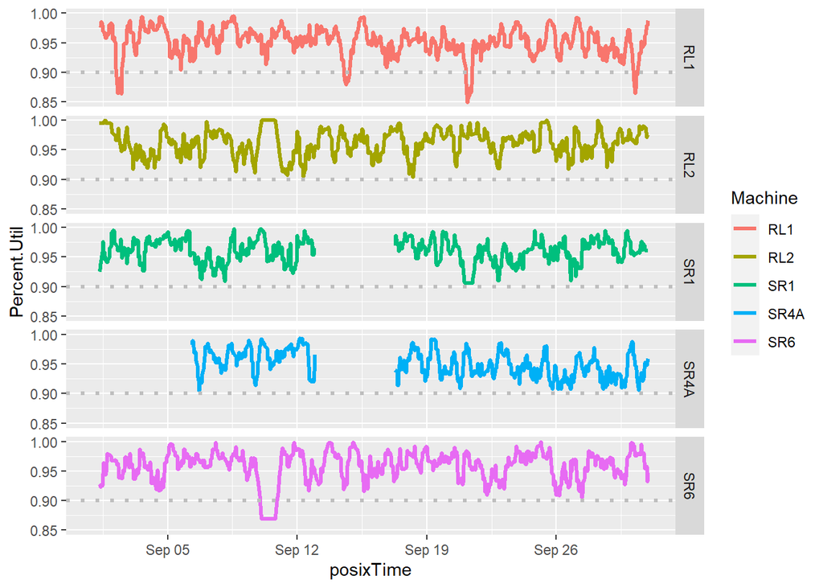

```r
p <- ggplot(data = dat)
myplot <- p + geom_line(aes(x=posixTime,y=Percent.Util,color=Machine),
              size=1.2)+facet_grid(rows = Machine~.) +
  geom_hline(yintercept = 0.9, color = "Gray", size = 1.2, linetype=3)
myplot
```

We can save the plot in a variable and store it in our list as well

```r
#RL1.List$Plot <- myplot
```